# Audit des R-Pakets sicr 1.1.1

Alle Zahlen in R gerechnet; Quellen in den Fußzeilen

## Methode in drei Runden

| Runde | Ordner | Ergebnis |
| --- | --- | --- |
| 1 – Audit | `analyse/`, `befunde/`, `verbesserungen/`, `bericht/` | 30 Fehler, 12 Verbesserungen, 46 eigene Prüfpunkte |
| 2 – Gegenprüfung | `gegenpruefung/` | alle 30 Fehler both-ways; E-F01 kritisch→hoch; „Anhang D“ widerlegt |
| 3 – Nachprüfung | `nachpruefung/` | F-F01 +5,95 %; D.11.4 ohne Paperbezug; 10/10 + 12/12 Mutanten |

Quelle: bericht/bericht.md, gegenpruefung/bericht.md, nachpruefung/bericht.md

## Ergebnis auf einen Blick

46Prüfpunkte  
31 konform · 10 konform (Fehler)  
2 abweichend · 2 optional · 1 ohne Paperbezug

30belegte Fehler  
0 kritisch · 8 hoch  
17 mittel · 5 niedrig

76Test-Blöcke  
200 Assertions  
alle grün

12Verbesserungen  
6 gemessen schneller  
2 langsamer, nur Lesbarkeit

Quellen: analyse/*.md, ergebnisse/testergebnisse.csv, nachpruefung/ergebnisse/benchmarks_spanne_zusammenfassung.csv

## Paperabgleich

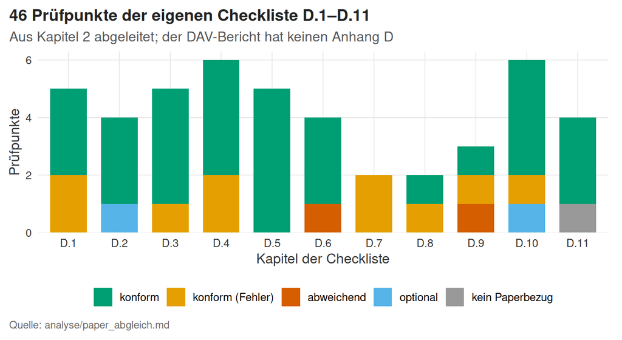

```r
grafik_paper(wurzel)
```

Kein Anhang D: Die 46 Punkte D.1–D.11 sind eine eigene Checkliste aus Kapitel 2 (S. 10–19). Der Bericht endet bei 3.2.9 (S. 58).

Quelle: analyse/paper_abgleich.md

## Fehler nach Schwere und Gruppe

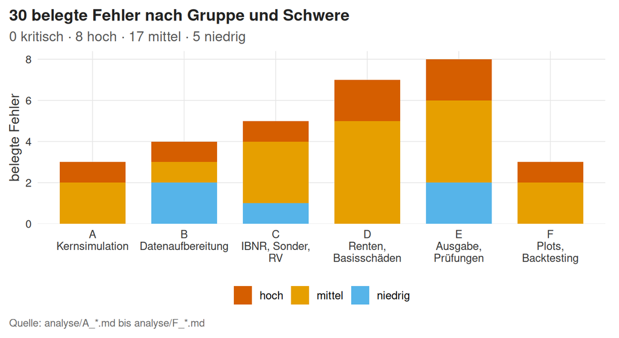

```r
grafik_schwere(wurzel)
```

Quelle: analyse/A_*.md bis analyse/F_*.md

## Wirkung der schweren Befunde

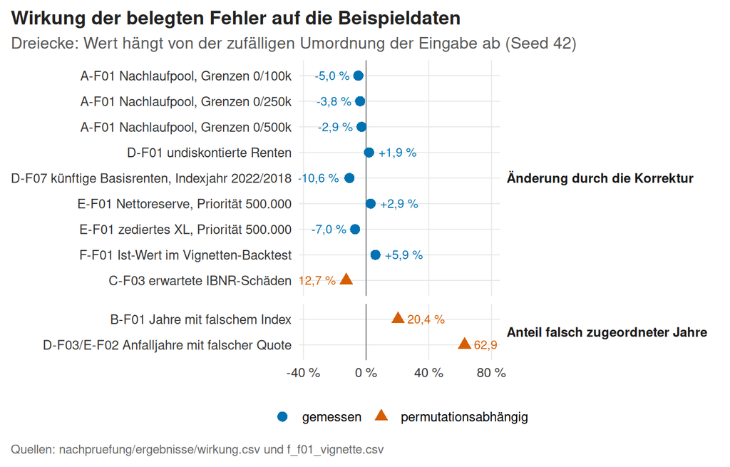

```r
grafik_wirkung(wurzel)
```

Quellen: nachpruefung/ergebnisse/wirkung.csv und f_f01_vignette.csv. Permutationswerte: Seed 42, Illustration.

## Belastbarkeit der Tests

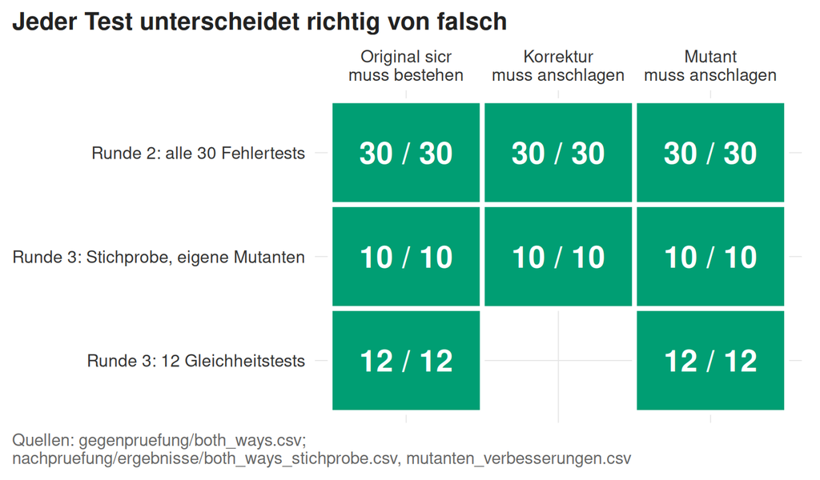

```r
grafik_testmatrix_kompakt(wurzel)
```

Runde 2: 30/30 both-ways. Runde 3: 10/10 eigene Mutanten, 12/12 Verbesserungsmutanten.

Quellen: gegenpruefung/both_ways.csv; nachpruefung/ergebnisse/both_ways_stichprobe.csv und mutanten_verbesserungen.csv

## Benchmarks als Spannen

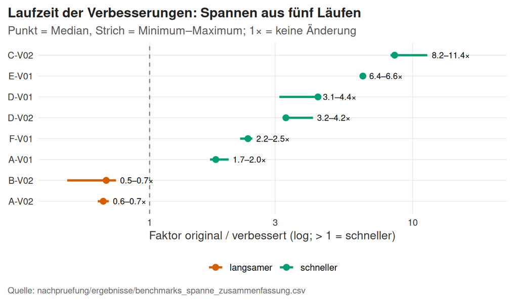

```r
grafik_benchmarks(wurzel)
```

Fünf Läufe: A-V01 1,7–2,0× · C-V02 8,2–11,4× · D-V01 3,1–4,4× · D-V02 3,2–4,2× · E-V01 6,4–6,6× · F-V01 2,2–2,5×. A-V02 und B-V02 sind langsamer und bleiben Lesbarkeitsverbesserungen.

Quelle: nachpruefung/ergebnisse/benchmarks_spanne_zusammenfassung.csv

## Was die Gegenprüfungen geändert haben

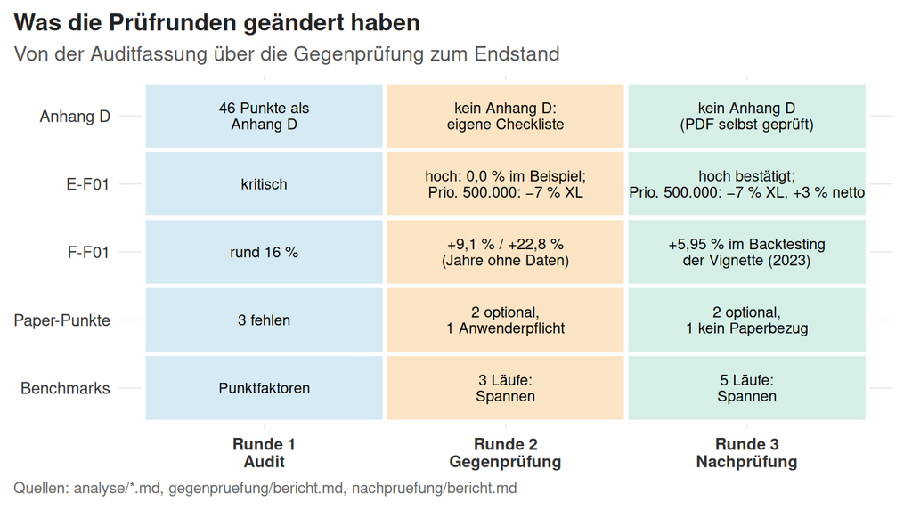

```r
grafik_runden(wurzel)
```

Quellen: analyse/*.md, gegenpruefung/bericht.md, nachpruefung/bericht.md

## Grenzen

- E-F01 ist mit **n = 1** und Seed 12345 gemessen; die Größe hängt vom Bestand und der Priorität ab.
- Die Permutationszahlen zu B-F01, C-F03 und D-F03/E-F02 sind **seed-abhängig** (Seed 42).
- Die eigenen Mutanten decken **10 der 30** Fehler ab, nicht alle.
- Die Verbesserungsmutanten verändern die **Ausgabe** der echten `_v()`, nicht deren Code.
- Das PDF wurde über **Textextraktion** durch einen Worker geprüft, nicht visuell Zeile für Zeile.

Quelle: nachpruefung/bericht.md, Abschnitt „Grenzen“

## Nächste Schritte

- `gegenpruefung/upstream.md` ist übergabereif; über eine Weitergabe entscheidet der **Owner**.
- Das **Ultimate-Backtesting** bleibt eine optionale Erweiterung (Anwendung der UAG, keine Paketanforderung).
- Die Wirkung auf **realen Beständen** ist offen; die Beispieldaten sind kein Portfolio.
- Die 46 Prüfpunkte sollten künftig als eigene Checkliste zitiert werden, nicht als „Anhang D“.

Quelle: gegenpruefung/upstream.md, nachpruefung/bericht.md

## Reproduktion

```bash
docker build -t aktuar-r:1 docker
docker run --rm -u "$(id -u):$(id -g)" -e HOME=/tmp -v "$PWD":/work -w /work aktuar-r:1 Rscript skripte/tests_ausfuehren.R
docker run --rm -u "$(id -u):$(id -g)" -e HOME=/tmp -v "$PWD":/work -w /work aktuar-r:1 Rscript skripte/render.R
```

Runde 3: siehe `nachpruefung/README.md` (wirkung.R, both_ways_stichprobe.R, mutanten_verbesserungen.R, benchmarks_spanne.R 5, f_f01_vignette.R).

Quelle: README.md, nachpruefung/README.md